# Analysis 6

Nishtha Arora

2023-03-25

Data sources: https://ourworldindata.org/mental-health

# 2000-2019

## Total Mental disorder

```r
library(readr)
library(tidyverse)
library(readxl)
library(lubridate)
library(themes360info)
```

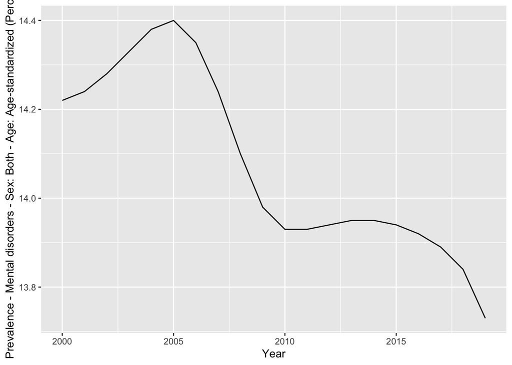

```r
total_mentaldis <- read_csv("data/analy5/share-with-mental-and-substance-disorders.csv") %>%
  filter(Entity == "India") %>%
  tail(20) %>%
select(-c(Entity, Code))

ggplot(total_mentaldis, aes(x=Year, y=`Prevalence - Mental disorders - Sex: Both - Age: Age-standardized (Percent)`))+
  geom_line()
```

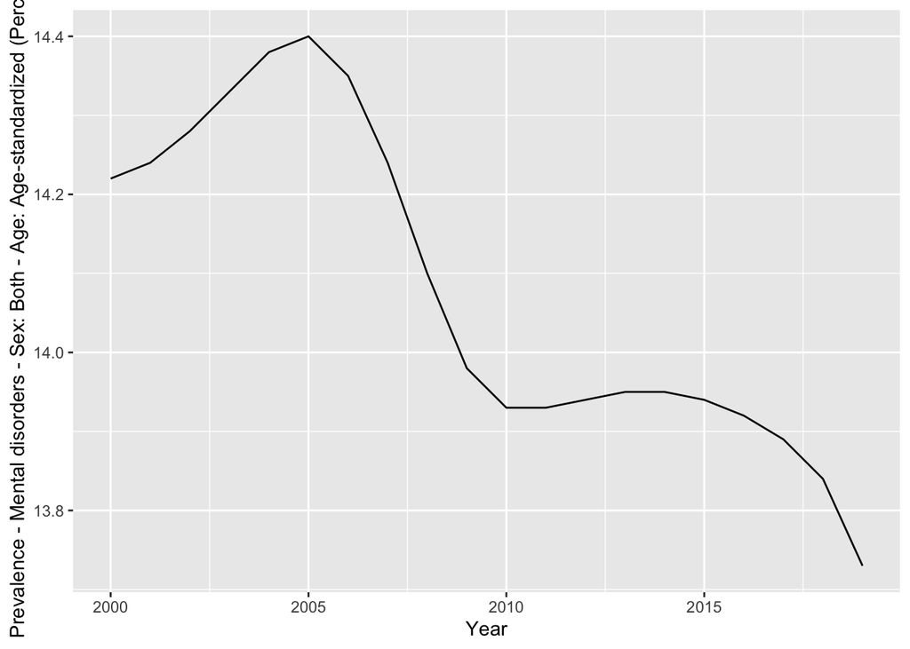

```r
suicide_vs_disorder <- read_csv("data/analy5/suicide-rates-vs-prevalence-of-mental-and-substance-use-disorders.csv") %>%
    filter(Entity == "India") %>%
  slice(11:30) %>%
  select(-c(Entity, Code))

ggplot(total_mentaldis, aes(x=Year, y=`Prevalence - Mental disorders - Sex: Both - Age: Age-standardized (Percent)`))+
  geom_line()
```

**Stress can cause mental health problems.And it can make existing problems worse. For example, if you experience lots of stress, this might lead you to develop a mental health problem like anxiety or depression.**

## Depression

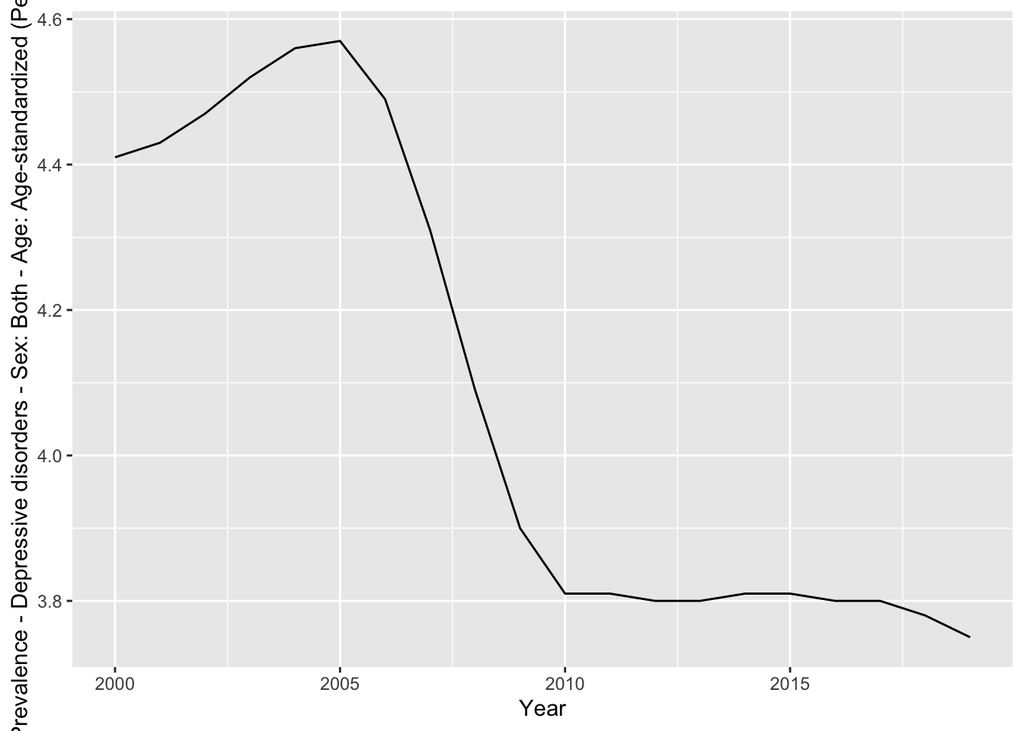

```r
depression <- read_csv("data/analy5/share-with-depression.csv") %>%
   filter(Entity == "India") %>%
  tail(20) %>%
  select(-c(Entity, Code))

ggplot(depression, aes(x=Year, y=`Prevalence - Depressive disorders - Sex: Both - Age: Age-standardized (Percent)`))+
  geom_line()
```

## Anxiety

**Anxiety disorders arise in a number of forms including phobic, social, obsessive compulsive (OCD), post-traumatic disorder (PTSD), or generalized anxiety disorders.**

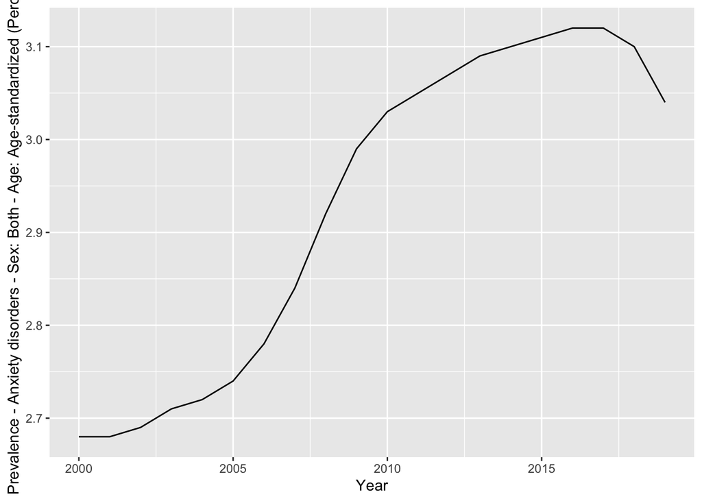

```r
anxiety<- read_csv("data/analy5/share-with-anxiety-disorders.csv") %>%
     filter(Entity == "India") %>%
  tail(20) %>%
  select(-c(Entity, Code))

ggplot(anxiety, aes(x=Year, y=`Prevalence - Anxiety disorders - Sex: Both - Age: Age-standardized (Percent)`))+
  geom_line()
```

## DALYs

**Health impacts are often measured in terms of total numbers of deaths, but a focus on mortality means that the burden of mental health disorders can be underestimated.2 Measuring the health impact by mortality alone fails to capture the impact that mental health disorders have on an individual’s wellbeing. The ’disease burden‘ – measured in Disability-Adjusted Life Years (DALYs) – considers not only the mortality associated with a disorder, but also years lived with disability or health burden. Mental health disorders as a share of total disease burden. Disease burden is measured in DALYs (Disability-Adjusted Life Years). DALYs measure total burden of disease, both from years of life lost and years lived with a disability. One DALY equals one lost year of healthy life.**

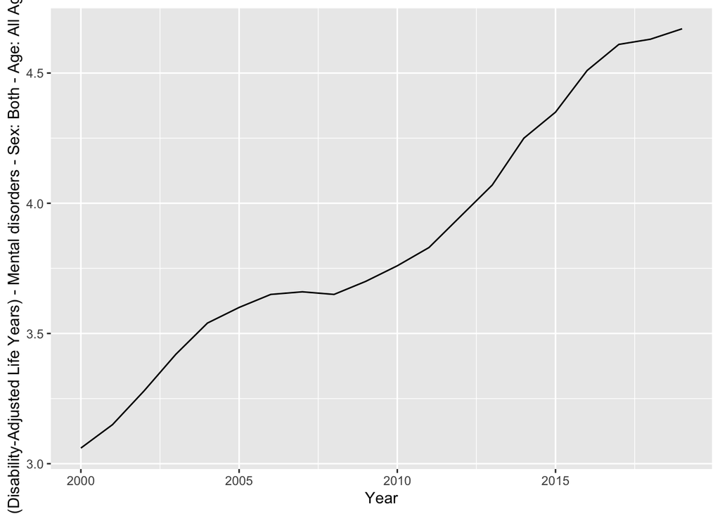

```r
mental_and_substance_use <- read_csv("data/analy5/mental-and-substance-use-as-share-of-disease.csv") %>%
      filter(Entity == "India") %>%
  tail(20) %>%
  select(-c(Entity, Code))

ggplot(mental_and_substance_use, aes(x=Year, y=`DALYs (Disability-Adjusted Life Years) - Mental disorders - Sex: Both - Age: All Ages (Percent)`))+
  geom_line()
```